# Elementary Quantitative Strategies

2023-12-23

## Visualizing Yearly Return via a bar graph

We use `PerformanceAnalytics` library for this task.

```r
# Import lib
library(dplyr)
library(quantmod)
library(PerformanceAnalytics)
library(ggplot2)
```

### Download prices

```r
getSymbols('SPY')
```

```
## [1] "SPY"
```

```r
prices = Cl(SPY)
head(prices)
```

```
##            SPY.Close
## 2007-01-03    141.37
## 2007-01-04    141.67
## 2007-01-05    140.54
## 2007-01-08    141.19
## 2007-01-09    141.07
## 2007-01-10    141.54
```

```r
tail(prices)
```

```
##            SPY.Close
## 2023-12-19  474.8400
## 2023-12-20  468.2600
## 2023-12-21  472.7000
## 2023-12-22  473.6500
## 2023-12-26  475.6500
## 2023-12-27  475.6801
```

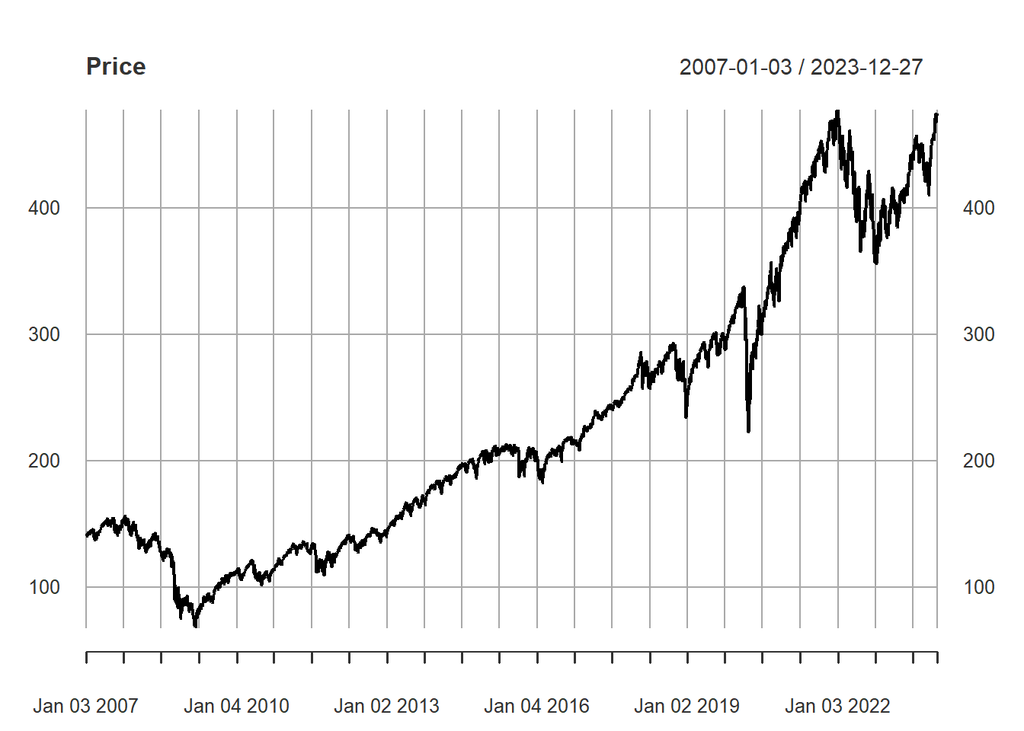

```r
plot(prices, main = "Price")
```

### Calculate yearly return series

Next, we convert prices to yearly return series with appropriate format.

Key is to use `fortify.zoo()`, which is used to convert a ‘zoo’ object into a dataframe that is suitable for plotting with ‘ggplot2’ or for manipulation with ‘dplyr’ functions.

```r
# Calculate to return series
ret_yearly = prices %>%
  Return.calculate() %>%
  apply.yearly(., Return.cumulative) %>%
  round(4) %>%
  fortify.zoo() %>%
  mutate(Index = as.numeric(substring(Index, 1, 4)))

ret_yearly
```

```
##    Index SPY.Close
## 1   2007    0.0342
## 2   2008   -0.3828
## 3   2009    0.2349
## 4   2010    0.1284
## 5   2011   -0.0020
## 6   2012    0.1347
## 7   2013    0.2969
## 8   2014    0.1129
## 9   2015   -0.0081
## 10  2016    0.0964
## 11  2017    0.1938
## 12  2018   -0.0635
## 13  2019    0.2879
## 14  2020    0.1616
## 15  2021    0.2704
## 16  2022   -0.1948
## 17  2023    0.2438
```

the code line `mutate(Index = as.numeric(substring(Index, 1, 4)))` indicates that we are taking only the years as the index value.

### Plot bar graph

Next, we plot it as a bar graph.

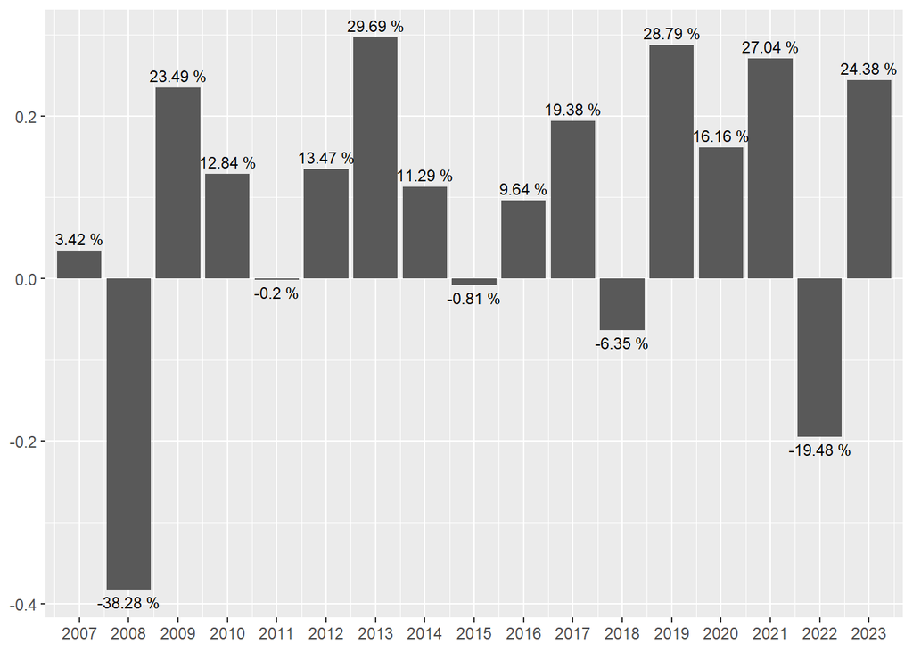

```r
ggplot(ret_yearly, aes(x = Index, y = SPY.Close)) +
  geom_bar(stat = 'identity') +
  scale_x_continuous(breaks = ret_yearly$Index,
                       expand = c(0.01, 0.01)) +
  geom_text(aes(label = paste(round(SPY.Close * 100, 2), "%"),
                vjust = ifelse(SPY.Close >= 0, -0.5, 1.5)),
            position = position_dodge(width = 1),
            size = 3) +
  xlab(NULL) + ylab(NULL)
```

#### Breakdown of ggplot2 code

**`geom_bar(stat = 'identity')`**: - `geom_bar()` adds bar geometries to the plot. By default, `geom_bar()` creates a histogram, which counts values for each category of the x-axis. However, by setting `stat = 'identity'`, it tells `ggplot` to use the y-values in the data as the bar heights directly. This is common when your y-values are already aggregated or calculated.

**`scale_x_continuous(breaks = ret_yearly$Index, expand = c(0.01, 0.01))`**: - `breaks = ret_yearly$Index` specifies where the ticks/markers on the x-axis should be placed. Here, it uses the `Index` values from `ret_yearly` as tick marks. - `expand = c(0.01, 0.01)` slightly expands the limits of the x-axis beyond the data to make the plot more visually appealing.

**`geom_text(aes(label = paste(round(SPY.Close * 100, 2), "%"), vjust = ifelse(SPY.Close >= 0, -0.5, 1.5)), position = position_dodge(width = 1), size = 3)`**: - `geom_text()` adds text labels to the plot. - Inside `aes()`, `label = paste(round(SPY.Close * 100, 2), "%")` creates the label for each bar. `SPY.Close` is rounded to two decimal places, multiplied by 100 (converting it to a percentage), and concatenated with a “%” symbol. - `vjust = ifelse(SPY.Close >= 0, -0.5, 1.5)` vertically adjusts the position of the text. If `SPY.Close` is positive (the bar goes upwards), the text is placed slightly above the bar (`-0.5`), otherwise below the bar (`1.5`). - `position = position_dodge(width = 1)` is used to position the text in the case of dodged bar plots. Here, it might not change much as the bars are not dodged.

**`xlab(NULL) + ylab(NULL)`**: - `xlab(NULL)` and `ylab(NULL)` remove the x and y-axis labels, respectively.

# Testing Basic Factor Investing Strategies

In Professor Lee’s book, he mostly focuses on mid-to-long term quant strategies, or portfolio theory based strategies. Thus, we will look at quantitative strategies that focus on using so-called *factors*.

## Calculating Market Beta

We first import necessary libraries.

```r
library(quantmod)
library(PerformanceAnalytics)
library(magrittr)
```

Next, we import closing prices for a single stock and a market index. We choose ‘AfreecaTV’ and ‘KOSPI 200 ETF’ in this case.

```r
# Read Tickers File
library(openxlsx)
tickers <- read.xlsx("KOR_ticker_2023-04-20.xlsx")

head(tickers)
```

```
##   종목코드         종목명     시가총액  종가   대비 등락률 시장구분    업종명
## 1   320000           윈텍 8.990586e+10  4860  -2070 -29.87   KOSDAQ 기계·장비
## 2   145210 다이나믹디자인 1.339975e+11  9490  -2730 -22.34    KOSPI      기계
## 3   010580     에스엠벡셀 3.582307e+11  3220   -730 -18.48    KOSPI  운수장비
## 4   000250     삼천당제약 1.836117e+12 79600 -14600 -15.50   KOSDAQ      제약
## 5   131100   초록뱀이앤엠 8.638862e+10  3080   -560 -15.38   KOSDAQ      유통
## 6   051980     중앙디앤엠 3.065040e+11  4865   -875 -15.24   KOSDAQ      화학
##   EPS PER 선행.EPS 선행.PER  BPS   PBR 주당배당금 배당수익률
## 1  36 135       NA       NA 1141  4.26          0          0
## 2  NA  NA       NA       NA 7920  1.20          0          0
## 3  NA  NA       NA       NA  494  6.52          0          0
## 4  NA  NA       NA       NA 7889 10.09          0          0
## 5  NA  NA       NA       NA 2921  1.05          0          0
## 6  NA  NA       NA       NA 1068  4.56          0          0
```

```r
tail(tickers)
```

```
##      종목코드         종목명     시가총액  종가 대비 등락률 시장구분
## 2331   030960         양지사 431460000000 27000 6200  29.81   KOSDAQ
## 2332   001000       신라섬유  58144708300  2395  550  29.81   KOSDAQ
## 2333   043090       엑서지21  92615327280  1866  430  29.94   KOSDAQ
## 2334   000760       이화산업  94080000000 33600 7750  29.98    KOSPI
## 2335   038530     골드퍼시픽  48676691999   529  122  29.98   KOSDAQ
## 2336   318160 셀바이오휴먼텍  90212078900 10100 2330  29.99   KOSDAQ
##             업종명   EPS   PER 선행.EPS 선행.PER   BPS  PBR 주당배당금
## 2331 출판·매체복제    NA    NA       NA       NA 13428 2.01         50
## 2332          유통    28 85.54       NA       NA   634 3.78          0
## 2333          유통    NA    NA       NA       NA   881 2.12          0
## 2334        유통업 16817  2.00       NA       NA 52259 0.64          0
## 2335          유통    NA    NA       NA       NA   758 0.70          0
## 2336     섬유·의류    NA    NA       NA       NA    NA   NA          0
##      배당수익률
## 2331       0.19
## 2332       0.00
## 2333       0.00
## 2334       0.00
## 2335       0.00
## 2336       0.00
```

```r
library(stringr)
```

```r
# Find appropriate tickers
tickers %>%
  filter(str_detect(종목명, "아프리카")) %>%
  select(종목코드) %>% pull()
```

```
## [1] "067160"
```

Notice that this is different from the format used when importing price data using Yahoo Finance’s API (.KS or .KQ is added).

In addition, the ticker data does not contain ticker info on ETFs.

Thus, we search for the tickers on the web. For KOSPI 200, we use Mirae Asset’s product, ‘Mirae Asset TIGER 200 ETF (102110.KS)’

```r
# Import price series
symbols <- c("067160.KQ", "102110.KS")

getSymbols(symbols)
```

```
## [1] "067160.KQ" "102110.KS"
```

```r
prices <- do.call(cbind,
                  lapply(symbols, function(x) Cl(get(x)))
)

ret <- Return.calculate(prices)

ret.3y <- ret['2021-01::2023-11']
ret.3y
```

```
##            X067160.KQ.Close X102110.KS.Close
## 2021-01-04      0.019834711     0.0246679317
## 2021-01-05     -0.011345219     0.0153086420
## 2021-01-06     -0.004918033    -0.0099708171
## 2021-01-07     -0.011532125     0.0228445099
## 2021-01-08      0.025000000     0.0447886647
## 2021-01-11     -0.006504065     0.0022985864
## 2021-01-12      0.075286416    -0.0075679395
## 2021-01-13      0.033485540     0.0048526863
## 2021-01-14     -0.001472754    -0.0001149822
## 2021-01-15     -0.016224189    -0.0211591536
##        ...
## 2023-11-17      0.001543210    -0.0055174471
## 2023-11-20      0.026194145     0.0077972710
## 2023-11-21     -0.024024024     0.0055051332
## 2023-11-22     -0.012307692     0.0004439183
## 2023-11-23      0.001557632     0.0008874427
## 2023-11-24     -0.001555210    -0.0081276784
## 2023-11-27     -0.012461059    -0.0010429082
## 2023-11-28      0.006309148     0.0122296793
## 2023-11-29      0.048589342    -0.0038308531
## 2023-11-30     -0.002989537     0.0051767490
```

One thing to note is that when using ret[‘start_date::end_date’], it is important to not include any space in between characters.

Next we conduct linear regression to find the beta coefficient of AfreecaTV wrt KOSPI 200.

```r
Af_ret.3y <- ret.3y[, 1]
market_ret.3y <- ret.3y[, 2]

# Fit linear model
market_beta.3y <- lm(Af_ret.3y ~ market_ret.3y)

summary(market_beta.3y)
```

```
##
## Call:
## lm(formula = Af_ret.3y ~ market_ret.3y)
##
## Residuals:
##      Min       1Q   Median       3Q      Max
## -0.13208 -0.01789 -0.00300  0.01483  0.18696
##
## Coefficients:
##                Estimate Std. Error t value Pr(>|t|)
## (Intercept)   0.0005485  0.0011683   0.469    0.639
## market_ret.3y 0.9300031  0.1066153   8.723   <2e-16 ***
## ---
## Signif. codes:  0 '***' 0.001 '**' 0.01 '*' 0.05 '.' 0.1 ' ' 1
##
## Residual standard error: 0.03071 on 689 degrees of freedom
##   (27 observations deleted due to missingness)
## Multiple R-squared:  0.09945,    Adjusted R-squared:  0.09815
## F-statistic: 76.09 on 1 and 689 DF,  p-value: < 2.2e-16
```

Usually, intercepts are close to zero or statistically non-significant. We see that market beta of AfreecaTV over the past three years is around 0.93, which is very close to 1.

Next, we try to calculate market betas for of AfreecaTV over 5 year, 2 year, 1 year, and 6 months and compare the beta coefficients.

```r
# 5 year market beta
ret.5y <- ret['2018-11::2023-11']

Af_ret.5y <- ret.5y[, 1]
market_ret.5y <- ret.5y[, 2]

# Fit linear model
market_beta.5y <- lm(Af_ret.5y ~ market_ret.5y)

summary(market_beta.5y)
```

```
##
## Call:
## lm(formula = Af_ret.5y ~ market_ret.5y)
##
## Residuals:
##       Min        1Q    Median        3Q       Max
## -0.131964 -0.017353 -0.002697  0.014201  0.187080
##
## Coefficients:
##                Estimate Std. Error t value Pr(>|t|)
## (Intercept)   0.0004823  0.0008313    0.58    0.562
## market_ret.5y 0.9340169  0.0672020   13.90   <2e-16 ***
## ---
## Signif. codes:  0 '***' 0.001 '**' 0.01 '*' 0.05 '.' 0.1 ' ' 1
##
## Residual standard error: 0.02903 on 1218 degrees of freedom
##   (33 observations deleted due to missingness)
## Multiple R-squared:  0.1369, Adjusted R-squared:  0.1362
## F-statistic: 193.2 on 1 and 1218 DF,  p-value: < 2.2e-16
```

```r
# 2 year market beta
ret.2y <- ret['2021-11::2023-11']

Af_ret.2y <- ret.2y[, 1]
market_ret.2y <- ret.2y[, 2]

# Fit linear model
market_beta.2y <- lm(Af_ret.2y ~ market_ret.2y)

summary(market_beta.2y)
```

```
##
## Call:
## lm(formula = Af_ret.2y ~ market_ret.2y)
##
## Residuals:
##       Min        1Q    Median        3Q       Max
## -0.128614 -0.016518 -0.002172  0.013669  0.191308
##
## Coefficients:
##                Estimate Std. Error t value Pr(>|t|)
## (Intercept)   -0.001805   0.001334  -1.353    0.177
## market_ret.2y  1.095195   0.122089   8.970   <2e-16 ***
## ---
## Signif. codes:  0 '***' 0.001 '**' 0.01 '*' 0.05 '.' 0.1 ' ' 1
##
## Residual standard error: 0.02944 on 485 degrees of freedom
##   (27 observations deleted due to missingness)
## Multiple R-squared:  0.1423, Adjusted R-squared:  0.1405
## F-statistic: 80.47 on 1 and 485 DF,  p-value: < 2.2e-16
```

```r
# 1 year market beta
ret.1y <- ret['2022-11::2023-11']

Af_ret.1y <- ret.1y[, 1]
market_ret.1y <- ret.1y[, 2]

# Fit linear model
market_beta.1y <- lm(Af_ret.1y ~ market_ret.1y)

summary(market_beta.1y)
```

```
##
## Call:
## lm(formula = Af_ret.1y ~ market_ret.1y)
##
## Residuals:
##       Min        1Q    Median        3Q       Max
## -0.131115 -0.015125 -0.002043  0.011995  0.187884
##
## Coefficients:
##                Estimate Std. Error t value Pr(>|t|)
## (Intercept)   -0.001513   0.001849  -0.819    0.414
## market_ret.1y  0.835120   0.182171   4.584 7.28e-06 ***
## ---
## Signif. codes:  0 '***' 0.001 '**' 0.01 '*' 0.05 '.' 0.1 ' ' 1
##
## Residual standard error: 0.02897 on 244 degrees of freedom
##   (23 observations deleted due to missingness)
## Multiple R-squared:  0.0793, Adjusted R-squared:  0.07553
## F-statistic: 21.02 on 1 and 244 DF,  p-value: 7.28e-06
```

```r
# six month market beta
ret.6m <- ret['2023-05::2023-11']

Af_ret.6m <- ret.6m[, 1]
market_ret.6m <- ret.6m[, 2]

# Fit linear model
market_beta.6m <- lm(Af_ret.6m ~ market_ret.6m)

summary(market_beta.6m)
```

```
##
## Call:
## lm(formula = Af_ret.6m ~ market_ret.6m)
##
## Residuals:
##       Min        1Q    Median        3Q       Max
## -0.132637 -0.012577 -0.000283  0.012557  0.105762
##
## Coefficients:
##                Estimate Std. Error t value Pr(>|t|)
## (Intercept)   -0.002721   0.002381  -1.143   0.2555
## market_ret.6m  0.599645   0.251733   2.382   0.0188 *
## ---
## Signif. codes:  0 '***' 0.001 '**' 0.01 '*' 0.05 '.' 0.1 ' ' 1
##
## Residual standard error: 0.02619 on 119 degrees of freedom
##   (23 observations deleted due to missingness)
## Multiple R-squared:  0.04551,    Adjusted R-squared:  0.03749
## F-statistic: 5.674 on 1 and 119 DF,  p-value: 0.0188
```

Interestingly, the we see market beta decrease when we reduce the time window from 2y -> 1y -> 6m.

We’ve seen correlation drop quite significantly for the last six months; this reflects the underperformance of AfreecaTV relative to the market index over the past few months.

### Calculating Rolling Beta

Now we try to calcualte a rolling beta of six trading months (252 / 2 ~ 126).

We use the `rollapply()` function from the ‘zoo’ package.

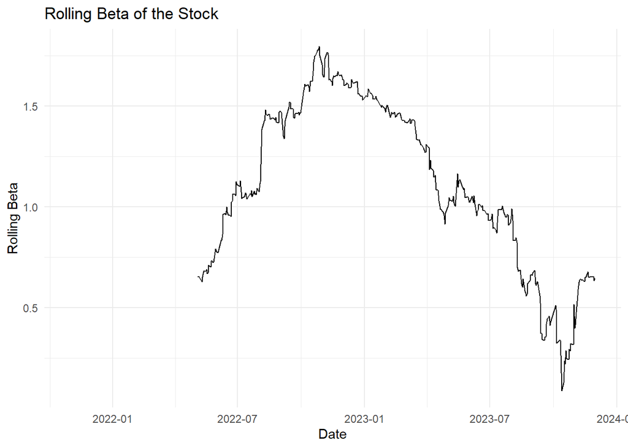

```r
# Define the rolling window size (days)
window_size <- 126

# Calculate rolling beta
rolling_beta <- rollapply(
  ret.2y,
  width = window_size,
  FUN = function(x) coef(lm(x[, 1] ~ x[, 2]))[2],
  by.column = FALSE,
  align = 'right'
)

# Create a time series object for plotting
rolling_beta_zoo <- zoo(rolling_beta, order.by = index(ret.2y))

# Plot the rolling beta
ggplot(data = fortify.zoo(rolling_beta_zoo), aes(x = Index, y = x)) +
  geom_line() +
  theme_minimal() +
  labs(title = 'Rolling Beta of the Stock', x = 'Date', y = 'Rolling Beta')
```

Clearly, market beta is not static; we should be careful of using beta as an input for any financial models without accounting for the variability and stability of beta over time.

### Visualizing Beta

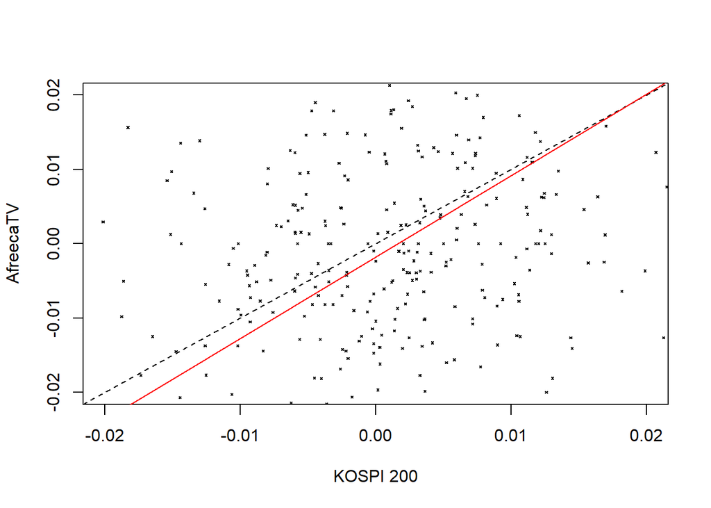

```r
plot(as.numeric(ret.2y[,2]), as.numeric(ret.2y[,1]), pch = 4, cex = 0.3,
     xlab = "KOSPI 200", ylab = "AfreecaTV",
     xlim = c(-0.02, 0.02), ylim = c(-0.02, 0.02))
abline(a = 0, b = 1, lty = 2)
abline(market_beta.2y, col = 'red')
```

## Low Vol Factor

There are three main points of why a low vol (beta) strategy achieves abnormal returns.

1. Investors often have overconfidence in their capabilities, resulting in investing too much in high-volatility stocks. This has the effect of lowering expected returns of these high-vol stocks relative to low-vol stocks, making the low-vol strat favorable.
2. Most institutional investors (pension funds, endowment funds, soverign funds, and mutual funds) cannot use leverage when investing. This implies that they would rather invest in high vol (beta) stocks than low vol (beta) stocks.
3. High-vol stocks are more subject to *volatility-drag*, causing returns to diminish over long run.

### Finding low-vol portfolio using daily returns

For this section, we import csv files that contain all publicly listed Korean stocks downloaded from *Naver Finance*. Below are the data used as of the date 12/26/2023 (when the code was executed)

1. 3y adjusted close price (2020/08/18 ~ 2023/08/18)
2. Ticker Information

First, we import the files

```r
# Import libraries
library(stringr)
library(xts)
library(PerformanceAnalytics)
library(magrittr)
library(ggplot2)
library(dplyr)
library(openxlsx)
```

Next, we import csv, xlsx files

```r
# Import ticker excel file
KOR_ticker <- read.xlsx("KOR_ticker_2023-04-20.xlsx")

# Import consolidated adj. closing price file
KOR_price <- read.csv("KOR_price/KOR_3Yadjclose_combined.csv")
```

next, we try to find the 30 lowest vol stock based on returns for past year.

First, I want to subset the data such that the new data frame only has the most recent year’s prices. There are many ways to achieve this, but I use ‘match-index’ method.

```r
# Subset the data
KOR_price$X <- as.Date(KOR_price$X)

start_date <- KOR_price[nrow(KOR_price),1] - 365
end_date <- KOR_price[nrow(KOR_price),1]

date_idx <- which(end_date >= KOR_price$X &  KOR_price$X >= start_date)

KOR_price.y1 <- KOR_price[date_idx,]

# Calculate Returns
ret_y1 = KOR_price.y1 %>%
  Return.calculate()
```

```r
# find standard deviations of all return series
apply(ret_y1, 2, sd) %>% head()
```

```
## X320000 X145210 X010580 X000250 X131100 X051980
##      NA      NA      NA      NA      NA      NA
```

We see that NA values are returned. This is probably because NA values were produced from the process of calculating returns (after subsetting the data into one year worth price series).

Thus, we drop the first row and the columns corresponding with NA values.

```r
# Handle NAs
na_col_idx <- which(colSums(is.na(ret_y1)) > 1)
names(na_col_idx) <- NULL

ret_y1 <- ret_y1[-1,]

ret_y1 <- ret_y1[, -na_col_idx]

# Check NA values
sum(is.na(ret_y1))
```

```
## [1] 0
```

We confirm there is no NA values, and we have exclude stocks with NA values. We save ticker + name of stocks that we have excluded for future reference (done later).

```r
# find standard deviations of all return series
std_12m_daily <- apply(ret_y1, 2, sd) %>% multiply_by(sqrt(252))
head(std_12m_daily, 50)
```

```
##   X320000   X145210   X010580   X000250   X131100   X051980   X014580   X037370
## 1.0534419 1.4372647 0.8736010 0.7042000 0.5719993 1.1793189 0.7570884 0.9102426
##   X011300   X006380   X396300   X125210   X348150   X025820   X285490   X051490
## 0.7181847 0.8749808 0.5550318 0.6478255 0.5457502 0.8110693 0.6071431 0.4862654
##   X076080   X299030   X018470   X065660   X042040   X005110   X159010   X074610
## 0.7197605 0.6442818 0.6996631 0.6303417 0.7397398 0.7620942 0.5295753 0.9587254
##   X317830   X029480   X053980   X049070   X225570   X075970   X044180   X340930
## 0.8179526 0.8105642 0.5180865 0.5568529 0.6526626 0.6944396 0.7447089 0.6394933
##   X270520   X094840   X361610   X334970   X351330   X234920   X012320   X054090
## 1.0634590 0.5659792 0.5564298 0.6949658 0.6592011 1.1439543 1.1017001 0.5447219
##   X263600   X294630   X263770   X005160   X126340   X042600   X338220   X002710
## 0.6145704 1.1160610 0.5270741 0.7840340 0.5729903 0.7735585 0.8421497 0.7862391
##   X049120   X227610
## 0.3510180 1.0812057
```

Note that we multiply each element by $\sqrt{252}$ to annualize the standard deviation calculated by daily returns. The reason why we multiply by the square root not 252 is because variance linearly scales, so we take the square root of the sum of random variables.

First, we take a look at the distribution of the standard deviation using a histogram.

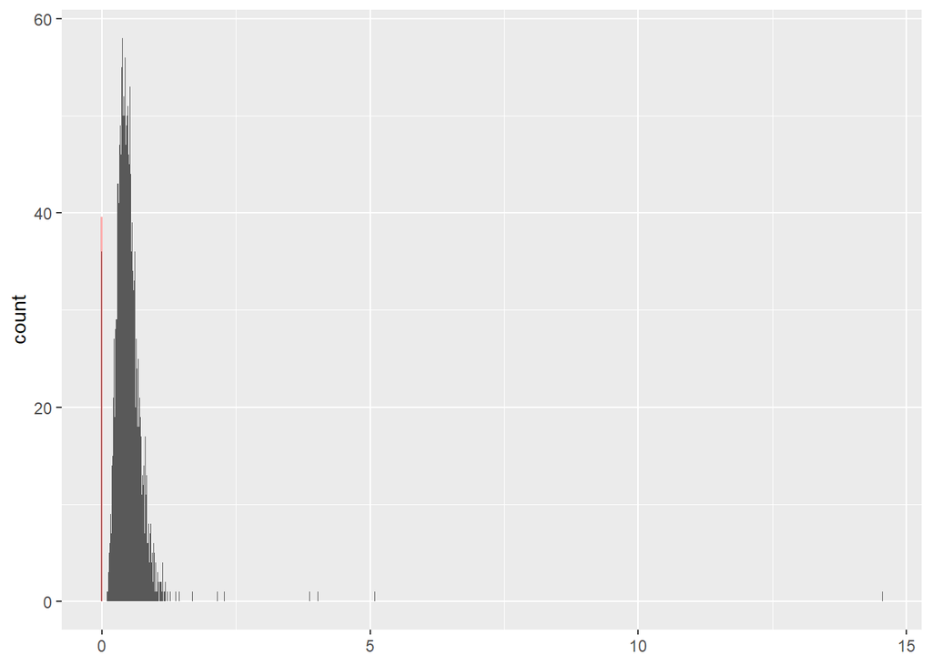

```r
# Plot sd as histogram
std_12m_daily %>%
  data.frame() %>%
  ggplot(aes(x = (`.`))) +
  geom_histogram(binwidth = 0.01) +
  annotate("rect", xmin = -0.02, xmax = 0.02,
           ymin = 0,
           ymax = sum(std_12m_daily == 0, na.rm = TRUE) * 1.1,
           alpha=0.3, fill="red") +
  xlab(NULL)
```

**Code Breakdown**

- The `annotate()` function adds a semi-transparent, red rectangle over the histogram with 0 standard deviation.
- It is important to notice that the value `aes(x=)` parameter is `(`.`)`. We must wrap *.* in backticks in order to successfully create a histogram representing distributions

Even after adjusting for stocks with not available prices in the most recent year, we see that many stocks have recorded a standard deviation of 0, meaning there was no change in price in this period.

This happens because there are stocks that have stopped trading, so price hasn’t changed for the past year.

There are a total of 36 stocks with 0 standard deviation.We exclude these stocks.

**Caution**

A word of caution. When excluding these stocks, you want to think about how to handle them. Do you want to remove them, or treat them as NA but still record those values. After some thought, one would realize the latter method is more convenient for future usage since the latter preserves the structure of the dataframe. That is, we could use the index derived from ranking the stds and subset the original dataset.

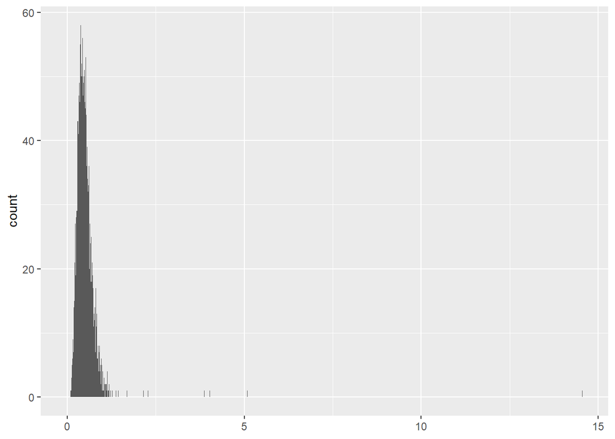

```r
# Input NA for stocks with 0 std
std_12m_daily[std_12m_daily == 0] <- NA

# Check new plot
std_12m_daily %>%
  data.frame() %>%
  ggplot(aes(x = (`.`))) +
  geom_histogram(binwidth = 0.01) +
  annotate("rect", xmin = -0.02, xmax = 0.02,
           ymin = 0,
           ymax = sum(std_12m_daily == 0, na.rm = TRUE) * 1.1,
           alpha=0.3, fill="red") +
  xlab(NULL)
```

```r
# Check which stock is ranked last (largest volatility)
which(rank(std_12m_daily) == length(std_12m_daily))
```

```
## X121890
##    1923
```

```r
# Check std of last ranked stock
std_12m_daily[1923]
```

```
## X121890
##      NA
```

It seems that NA-valued stocks are automatically moved to the lower ranks. Then, it would make sense that we should check the stock whose rank is
$$(\text{length of} \ \sigma \
vector) - (\text{number of NA values})$$
.

```r
sum(is.na(std_12m_daily))
```

```
## [1] 36
```

```r
length(std_12m_daily) - sum(is.na(std_12m_daily))
```

```
## [1] 2245
```

```r
# Check index of stock whose rank is 2245
which(rank(std_12m_daily) == (length(std_12m_daily) - sum(is.na(std_12m_daily))))
```

```
## X139050
##     757
```

```r
# Std of 757th stock
std_12m_daily[757]
```

```
##  X139050
## 14.55317
```

To make sure our hypothesis is correct, we also check the stock of the one rank lower.

```r
# Check index of stock whose rank is 2246
which(rank(std_12m_daily) == (1 + length(std_12m_daily) - sum(is.na(std_12m_daily))))
```

```
## X136510
##    1798
```

```r
# Std of 1798th stock
std_12m_daily[1798]
```

```
## X136510
##      NA
```

As predicted, all NA values were moved to the last rank, so we should look at the rank of the stocks excluding NA values. Another way is to just simply set `rank(na.last = NA)` to not include NA values at all when ranking the input.

```r
# Return series for highest vol stock
ret_y1 %>% select(757) %>% head()
```

```
##                X139050
## 2022-08-19  0.01018676
## 2022-08-22 -0.02016807
## 2022-08-23  0.03259005
## 2022-08-24 -0.02325581
## 2022-08-25  0.01530612
## 2022-08-26  0.03685092
```

#### Ranking stocks by std

We choose stocks with ranks equal to or higher than 30.

First, we visually check their volatility using ggplot.

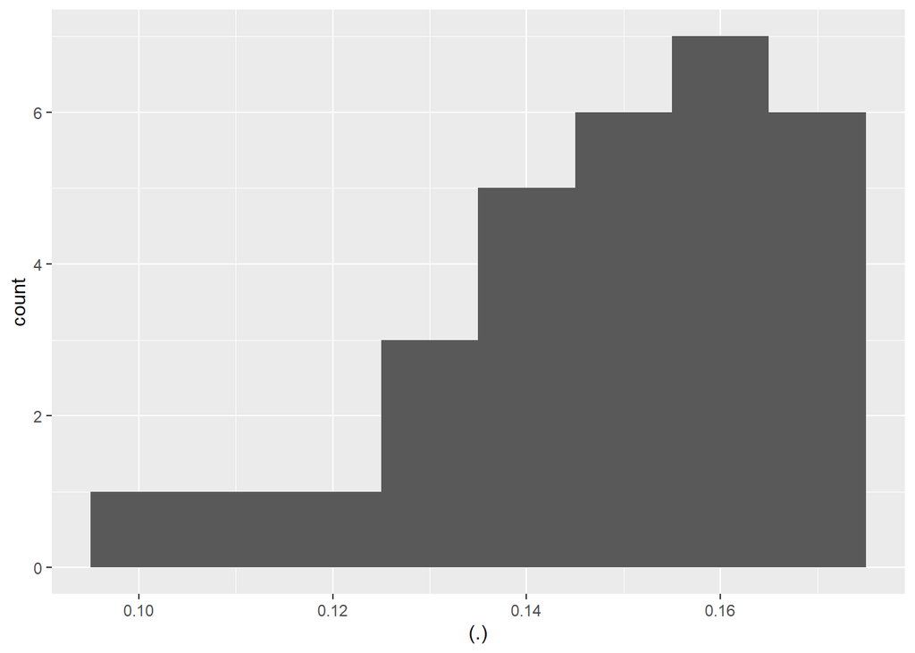

```r
# Plot histogram of std of top 30 stocks by low volatility
std_12m_daily[rank(std_12m_daily) <= 30] %>% data.frame() %>%
  ggplot(aes(x =(`.`))) +
  geom_histogram(binwidth = 0.01)
```

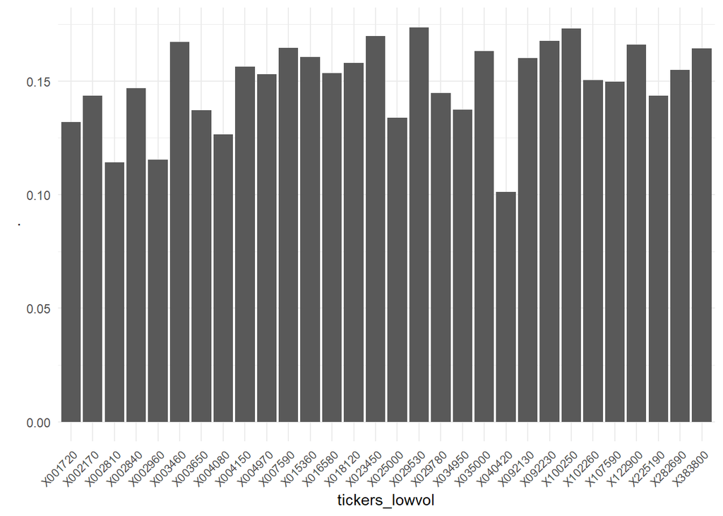

```r
# Plot bar graph of the 30 stocks
tickers_lowvol <- std_12m_daily[rank(std_12m_daily) <= 30] %>% data.frame() %>% rownames()

std_12m_daily[rank(std_12m_daily) <= 30] %>%
  data.frame() %>%
  ggplot(aes(x = tickers_lowvol, y = `.`)) +
  geom_col() +
  theme_minimal() +
  theme(axis.text.x = element_text(angle = 45, hjust = 1, size = 8)) +
  theme(plot.margin = margin(5.5, 5.5, 5.5, 5.5, "pt"))
```

**Code Breakdown**

- `theme(axis.text.x = element_text(angle = 45, hjust = 1, size = 8))`: this line of code adjusts the axis labels by rotating in 45 degrees, aligning horizontally by the end, and then sizing the axis labels appropriately, such that no overlaps occur.

Lastly, we save the info on these 30 stocks for building our future portfolio using *KOR_ticker.xlsx* file.

We will save:

1. Stock code
2. Stock name
3. Market cap
4. Sector name
5. Annualized stock volatility

```r
invest_lowvol <- rank(std_12m_daily) <= 30

# Store all necessary info
KOR_ticker[invest_lowvol, ] %>% select('종목코드', '종목명', '시가총액', '업종명') %>%
  mutate('변동성' = std_12m_daily[rank(std_12m_daily) <= 30] %>% round(4))
```

```
##      종목코드           종목명     시가총액        업종명 변동성
## 894    000860     강남제비스코 1.833000e+11          화학 0.1580
## 1419   129260         인터지스 7.674951e+10    운수창고업 0.1606
## 1471   005390         신성통상 3.046618e+11        유통업 0.1671
## 1473   027040     서울전자통신 4.105742e+10          유통 0.1371
## 1512   377300       카카오페이 7.485288e+12      기타금융 0.1697
## 1567   063570     한국전자금융 1.843977e+11    기타서비스 0.1562
## 1569   104200          NHN벅스 9.608252e+10  디지털컨텐츠 0.1730
## 1587   005420       코스모화학 2.422569e+12          화학 0.1535
## 1596   213500         한솔제지 2.796568e+11      종이목재 0.1644
## 1597   002290     삼일기업공사 4.377200e+10          건설 0.1661
## 1620   026910         광진실업 2.911257e+10          금속 0.1530
## 1631   005670           푸드웰 5.410000e+10   음식료·담배 0.1601
## 1683   164060           이루다 1.309011e+11 의료·정밀기기 0.1374
## 1745   207940 삼성바이오로직스 5.587159e+13        의약품 0.1339
```

[output cut: 16 more lines]

An interesting observation is that the *LG에너지솔루션* is included in one of the lowest volatility yielding stocks, using one year returns starting from 2022-08-18.

By the way, since 2023-08-18, the stock has tanked more than 20% (as of 2023-12-26).

### Finding low-vol portfolio using weekly returns

For consistency of results, we could go through the same process as above but this time using weekly returns.

Then we would look at the intersection of the two groups and select the common stocks to formulate a low-vol portfolio.

```r
# Calculate sdv based on weekly returns
std_12m_weekly <- ret_y1 %>% apply.weekly(Return.cumulative) %>%
  apply(., 2, sd) %>%
  multiply_by(sqrt(52))

head(std_12m_weekly, 50)
```

```
##   X320000   X145210   X010580   X000250   X131100   X051980   X014580   X037370
## 1.0002893 1.9824696 0.7845136 0.7464375 0.4075527 1.5435893 0.6300774 0.8972995
##   X011300   X006380   X396300   X125210   X348150   X025820   X285490   X051490
## 0.7076786 0.9783386 0.5470370 0.5174389 0.5446765 0.6084797 0.6456273 0.5194355
##   X076080   X299030   X018470   X065660   X042040   X005110   X159010   X074610
## 0.6162733 0.5770653 0.6050741 0.7716050 0.6128817 0.5145067 0.5178832 0.9590138
##   X317830   X029480   X053980   X049070   X225570   X075970   X044180   X340930
## 0.7123084 0.8957501 0.5122573 0.4451862 0.6529126 0.6387394 1.0221448 0.5963235
##   X270520   X094840   X361610   X334970   X351330   X234920   X012320   X054090
## 1.4752081 0.4289118 0.5585423 0.6152506 0.5316650 1.6912019 1.5324549 0.5029342
##   X263600   X294630   X263770   X005160   X126340   X042600   X338220   X002710
## 0.5103236 1.8143693 0.5057292 0.6733855 0.5912757 0.9235025 0.8080236 0.9122114
##   X049120   X227610
## 0.2795130 1.3375970
```

**Notes**

- We use `apply.weekly()` and input `Return.cumulative()` function to calculate weekly returns. We can apply this method to find monthly and yearly returns as well (`apply.monthly()`, `apply.yearly()`)
- To annualise the standard deviations, we multiply $\sqrt{52}$, but notice that there are 53 observations. If we needed accurate annualized figures, then we should multiply by instead $\sqrt{53})$. However, since we are only interested in rankings, this detail does not change our final results.

Next, we repeat previous steps to find the 30 stocks with lowest annualised volatility.

```r
# Replace 0 sdv stocks with NA
std_12m_weekly[std_12m_weekly == 0] <- NA
std_12m_weekly[rank(std_12m_weekly) <= 30]
```

```
##    X015360    X003650    X023450    X016580    X122900    X036190    X034950
## 0.13916587 0.12549170 0.15693887 0.13274950 0.12773663 0.15667032 0.15223185
##    X008470    X130580    X025000    X001720    X007590    X225190    X002810
## 0.11731085 0.14089248 0.09832678 0.10635935 0.13242418 0.15061916 0.10673990
##    X017670    X016800    X102260    X092230    X002210    X004080    X006090
## 0.15419307 0.14058367 0.15406249 0.13752919 0.15388442 0.08812171 0.14211255
##    X002840    X040420    X035000    X002960    X107590    X078000    X029780
## 0.14891055 0.09734835 0.14447795 0.11158999 0.15529758 0.15604976 0.15666102
##    X002170    X000650
## 0.14235833 0.15200625
```

```r
invest_lowvol_weekly <- rank(std_12m_weekly) <= 30

KOR_ticker[invest_lowvol_weekly, ] %>% select('종목코드', '종목명', '시가총액', '업종명') %>%
  mutate('변동성' = std_12m_weekly[rank(std_12m_weekly) <= 30] %>% round(4))
```

```
##      종목코드           종목명     시가총액        업종명 변동성
## 1419   129260         인터지스 7.674951e+10    운수창고업 0.1392
## 1473   027040     서울전자통신 4.105742e+10          유통 0.1255
## 1512   377300       카카오페이 7.485288e+12      기타금융 0.1569
## 1587   005420       코스모화학 2.422569e+12          화학 0.1327
## 1597   002290     삼일기업공사 4.377200e+10          건설 0.1277
## 1670   032800         판타지오 4.389310e+10     오락·문화 0.1567
## 1683   164060           이루다 1.309011e+11 의료·정밀기기 0.1522
## 1697   025550         한국선재 1.065155e+11          금속 0.1173
## 1723   005740 크라운해태홀딩스 9.428065e+10      기타금융 0.1409
## 1745   207940 삼성바이오로직스 5.587159e+13        의약품 0.0983
## 1750   373220   LG에너지솔루션 1.357200e+14      전기전자 0.1064
## 1759   009810       플레이그램 1.095600e+11        유통업 0.1324
## 1775   072870       메가스터디 1.389984e+11 출판·매체복제 0.1506
## 1778   071840     롯데하이마트 2.797514e+11        유통업 0.1067
```

[output cut: 16 more lines]

Next, we look at the intersections between two groups and categorize these stocks as the *true* low-volatility stocks.

```r
intersect(KOR_ticker[invest_lowvol, '종목명'],
          KOR_ticker[invest_lowvol_weekly, '종목명'])
```

```
##  [1] "인터지스"         "서울전자통신"     "카카오페이"       "코스모화학"
##  [5] "삼일기업공사"     "이루다"           "삼성바이오로직스" "LG에너지솔루션"
##  [9] "플레이그램"       "메가스터디"       "롯데하이마트"     "모토닉"
## [13] "에이플러스에셋"   "GKL"              "세기상사"         "엔시트론"
## [17] "KH 전자"          "에스엘바이오닉스" "동부건설"         "대우조선해양"
## [21] "씨아이테크"
```

There are 21 overlapping stocks, which we can potentially include in a low-vol stock based on annual volatility.

## Momentum Factor

We can think of momentum existing in two different ways:

1. Earnings momentum
2. Price momentum

We will select stocks to include in a price momentum portfolio based on the most recent 12 month returns.

We will use these files:

1. KOR_price: consolidated price csv file
2. KOR_tickers: xlsx file containing stock name, ticker, and etc

```r
# Import libraries
library(stringr)
library(xts)
library(PerformanceAnalytics)
library(magrittr)
library(dplyr)
library(openxlsx)
```

```r
# Import ticker excel file
KOR_ticker <- read.xlsx("KOR_ticker_2023-04-20.xlsx")

# Import consolidated adj. closing price file
KOR_price <- read.csv("KOR_price/KOR_3Yadjclose_combined.csv")

KOR_price.xts <- as.xts(KOR_price[,-1], order.by = as.Date(KOR_price$X))

head(KOR_ticker)
```

```
##   종목코드         종목명     시가총액  종가   대비 등락률 시장구분    업종명
## 1   320000           윈텍 8.990586e+10  4860  -2070 -29.87   KOSDAQ 기계·장비
## 2   145210 다이나믹디자인 1.339975e+11  9490  -2730 -22.34    KOSPI      기계
## 3   010580     에스엠벡셀 3.582307e+11  3220   -730 -18.48    KOSPI  운수장비
## 4   000250     삼천당제약 1.836117e+12 79600 -14600 -15.50   KOSDAQ      제약
## 5   131100   초록뱀이앤엠 8.638862e+10  3080   -560 -15.38   KOSDAQ      유통
## 6   051980     중앙디앤엠 3.065040e+11  4865   -875 -15.24   KOSDAQ      화학
##   EPS PER 선행.EPS 선행.PER  BPS   PBR 주당배당금 배당수익률
## 1  36 135       NA       NA 1141  4.26          0          0
## 2  NA  NA       NA       NA 7920  1.20          0          0
## 3  NA  NA       NA       NA  494  6.52          0          0
## 4  NA  NA       NA       NA 7889 10.09          0          0
## 5  NA  NA       NA       NA 2921  1.05          0          0
## 6  NA  NA       NA       NA 1068  4.56          0          0
```

```r
head(KOR_price.xts[,1:10])
```

```
##            X320000 X145210 X010580 X000250 X131100 X051980 X014580 X037370
## 2020-08-18    2900   27370    2295   48700   12925    2372    3650    8260
## 2020-08-19    2775   27370    2295   52100   13400    2400    3685    8230
## 2020-08-20    2640   26650    2295   51800   12975    2438    3485    7930
## 2020-08-21    2730   28570    2295   51500   13425    2357    3570    7860
## 2020-08-24    2750   27850    2295   55200   13400    2248    3540    7810
## 2020-08-25    2985   29411    2295   58100   13175    2921    3640    8130
##            X011300 X006380
## 2020-08-18     440    2530
## 2020-08-19     459    2565
## 2020-08-20     434    2455
## 2020-08-21     441    2465
## 2020-08-24     442    2460
## 2020-08-25     449    2500
```

### Construct Momentum portfolio based on recent 12m returns

Now we calculate returns.

```r
ret <- Return.calculate(KOR_price.xts) %>% xts::last(252)

# Calculate 12 month cumulative returns
cumret_12m <- ret %>% sapply(., function(x) {
  prod(1+x) -1
})

# Find ranking (30) of highest 12m cumulative returns
cumret_12m[rank(-cumret_12m) <= 30]
```

```
##   X051980   X234920   X338220   X328130   X047050   X336570   X006110   X017370
##  2.913043  5.109091  3.714286  2.738386  2.614191  3.306931  3.000000  2.606004
##   X009520   X065350   X117730   X322510   X139050   X101670   X109960   X277810
##  2.633194  3.930041  2.938272  5.309055  7.750000  8.292035  2.585227  3.049734
##   X001570   X007660   X087010   X304100   X086520   X022100   X317770   X006740
## 10.618182  4.035461  2.817204  2.787129  8.308925  3.788618  3.658652 13.616871
##   X042700   X114190   X025560   X079810   X058970   X011810
##  3.605578  3.542857  3.375338  3.048125  3.646865  5.942496
```

Next, we extract necessary info from the ticker file.

```r
invest_mom_12m <- rank(-cumret_12m) <= 30

KOR_ticker[invest_mom_12m,] %>%
  select("종목명", "종목코드", "시가총액", "업종명") %>%
  mutate('12 month cumret' = cumret_12m[invest_mom_12m] %>% round(4))
```

```
##                종목명 종목코드     시가총액        업종명 12 month cumret
## 6          중앙디앤엠   051980 3.065040e+11          화학          2.9130
## 42             자이글   234920 2.888849e+11  일반전기전자          5.1091
## 51               뷰노   338220 2.170191e+11    소프트웨어          3.7143
## 83               루닛   328130 6.532014e+11    소프트웨어          2.7384
## 108  포스코인터내셔널   047050 5.128149e+12        유통업          2.6142
## 183              원텍   336570 5.724045e+11 의료·정밀기기          3.3069
## 215        삼아알미늄   006110 1.241686e+12      철강금속          3.0000
## 375        우신시스템   017370 5.512530e+10          기계          2.6060
## 402        포스코엠텍   009520 1.251363e+12          금속          2.6332
## 454      신성델타테크   065350 3.243106e+11  일반전기전자          3.9300
## 544        티로보틱스   117730 2.287355e+11     기계·장비          2.9383
## 577        제이엘케이   322510 9.529148e+10    소프트웨어          5.3091
## 794          시티랩스   139050 3.968085e+10  컴퓨터서비스          7.7500
## 836      하이드로리튬   101670 9.893674e+11          금속          8.2920
```

[output cut: 16 more lines]

#### Momentum portfolio based on risk-adjusted 12m returns

Though we could use above stocks to form our long portfolio, note that we are completely ignoring volatility.

Thus, it would be make more sense to use the annualized standard deviation to find risk-adjusted performance and then form a ranked portfolio.

Then, we can look at intersections between the two groups to choose final components for our momentum portfolio.

```r
# Calculate 12 month sdv and then annualize it
sdv_12m <- ret %>% apply(., 2, sd) %>% multiply_by(sqrt(252))

# Calculate 12m sharpe
sharpe_mom_12m <- cumret_12m/sdv_12m

sharpe_mom_12m[rank(-sharpe_mom_12m) <= 30]
```

```
##   X234920   X338220   X335890   X352480   X328130   X047050   X336570   X006110
##  4.501241  4.434780  4.119360  4.306203  3.179601  3.575676  6.041051  3.947725
##   X017370   X065350   X095340   X117730   X322510   X033100   X101670   X277810
##  3.888160  4.306481  3.578815  3.884220  6.062877  3.614156  6.037187  3.490962
##   X001570   X007660   X087010   X086520   X031980   X281740   X022100   X006740
##  9.574743  5.214376  3.299421  9.119491  3.631696  3.236828  4.711431 20.045723
##   X042700   X114190   X025560   X079810   X058970   X011810
##  5.229722  3.639786  3.486961  3.885514  4.547417  5.017523
```

```r
# Extract necessary info
invest_mom_sharpe_12m <- rank(-sharpe_mom_12m) <= 30

KOR_ticker[invest_mom_sharpe_12m,] %>%
  select("종목명", "종목코드", "시가총액", "업종명") %>%
  mutate('12 month cumret' = cumret_12m[invest_mom_12m] %>% round(2),
         '12m vol' =  sdv_12m[invest_mom_12m] %>% round(2),
         '12 month sharpe' = sharpe_mom_12m[invest_mom_sharpe_12m] %>% round(2))
```

```
##                종목명 종목코드     시가총액        업종명 12 month cumret
## 42             자이글   234920 2.888849e+11  일반전기전자            2.91
## 51               뷰노   338220 2.170191e+11    소프트웨어            5.11
## 60               비올   335890 3.079990e+11 의료·정밀기기            3.71
## 79   씨앤씨인터내셔널   352480 3.700151e+11          화학            2.74
## 83               루닛   328130 6.532014e+11    소프트웨어            2.61
## 108  포스코인터내셔널   047050 5.128149e+12        유통업            3.31
## 183              원텍   336570 5.724045e+11 의료·정밀기기            3.00
## 215        삼아알미늄   006110 1.241686e+12      철강금속            2.61
## 375        우신시스템   017370 5.512530e+10          기계            2.63
## 454      신성델타테크   065350 3.243106e+11  일반전기전자            3.93
## 526               ISC   095340 6.542201e+11        반도체            2.94
## 544        티로보틱스   117730 2.287355e+11     기계·장비            5.31
## 577        제이엘케이   322510 9.529148e+10    소프트웨어            7.75
## 744          제룡전기   033100 2.563560e+11        IT부품            8.29
```

[output cut: 47 more lines]

Then we find the intersecting stocks.

```r
intersect(KOR_ticker[invest_mom_12m, "종목명"], KOR_ticker[invest_mom_sharpe_12m, "종목명"])
```

```
##  [1] "자이글"           "뷰노"             "루닛"             "포스코인터내셔널"
##  [5] "원텍"             "삼아알미늄"       "우신시스템"       "신성델타테크"
##  [9] "티로보틱스"       "제이엘케이"       "하이드로리튬"     "레인보우로보틱스"
## [13] "금양"             "이수페타시스"     "펩트론"           "에코프로"
## [17] "포스코DX"         "영풍제지"         "한미반도체"       "강원에너지"
## [21] "미래산업"         "디이엔티"         "엠로"             "STX"
```

We see 24 intersecting stocks. From those, we notice “금양”, “에코프로”, and “영풍제지”. These stocks were all featured in the news and hot for their craze-fueled rally.

Next, we plot the top 30 stocks based on risk adjusted performance.

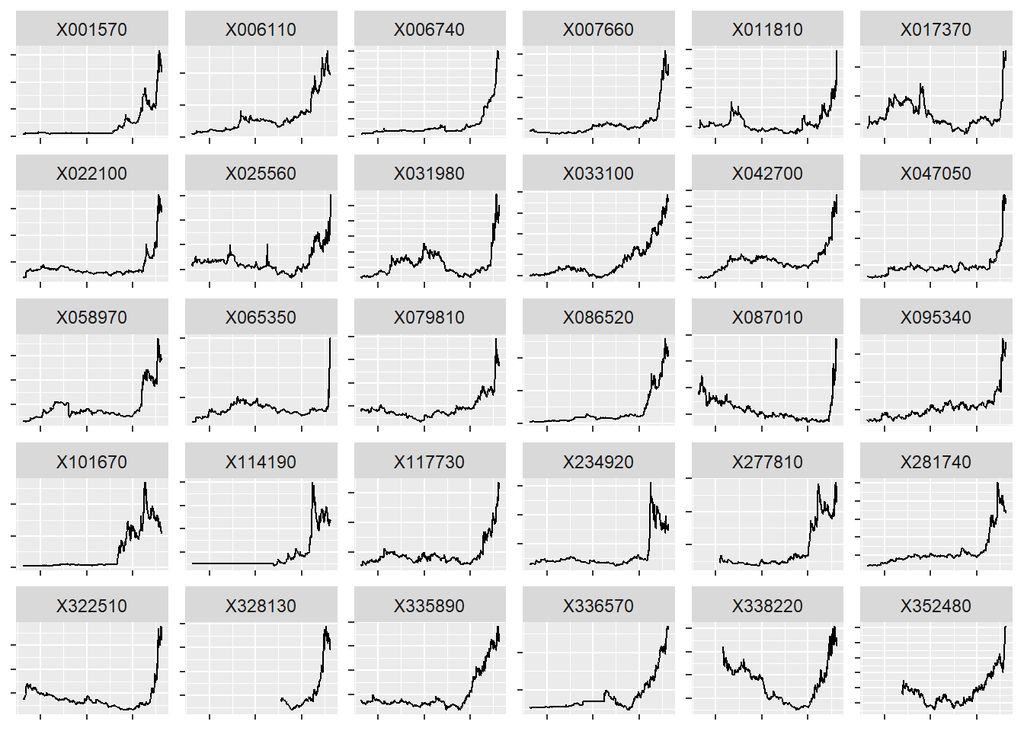

```r
library(xts)
library(tidyr)
library(ggplot2)

KOR_price.xts[, invest_mom_sharpe_12m] %>%
  fortify.zoo() %>%
  gather(ticker, price, -Index) %>%
  ggplot(aes(x = Index, y = price)) +
  geom_line() +
  facet_wrap(. ~ ticker, scales = 'free') +
  xlab(NULL) +
  ylab(NULL) +
  theme(axis.text.x=element_blank(),
        axis.text.y=element_blank())
```

**Code Breakdown**

- **`gather(ticker, price, -Index) %>%`**: The `gather()` function is used to transform the data from a wide format to a long format. In the resulting dataframe, there will be columns named `ticker`, `price`, and `Index`. The `ticker` column contains what were originally column names, and `price` contains the corresponding values. The `-Index` indicates that the `Index` column (time/date) is to be preserved as is.
- **`facet_wrap(. ~ ticker, scales = 'free')`**: Creates separate plots (facets) for each `ticker`, arranged in a grid. The `scales = 'free'` argument allows each facet to have its own y-axis scale, which is useful when the data range varies significantly across tickers.
- **`xlab(NULL)` and `ylab(NULL)`**: Removes labels from the x-axis and y-axis.
- **`theme(...)`**: Customizes the plot’s theme. Here, it’s used to remove the text from the x-axis (`axis.text.x=element_blank()`) and y-axis (`axis.text.y=element_blank()`).

A common element we see from the plot is that many of the stocks have shown exponential growth in price in the very last few months.

## Value Factor

Value factors are one of the well-known factors, being promoted by famous value investors such as Benjamin Graham and Warren Buffett.

There are both risk-based explanations and behavior-based explanations.

**Risk-based explanation**

- value stocks are priced low because of valid economic risks of the underlying companies. Thus, investors should be rewarded for holding stocks with a *low potential*.

**Behavior-based explanation**

- value stocks are overlooked by investors and instead people tend to favor *glamour stocks*, or growth stocks. As a result, these glamour stocks are generally overpriced and value stocks underpriced, even if there is real chance of a turnaround.

### Construct Value Portfolio based on PBR

The most widely used metric for constructing value portfolios is *PBR*. Moreover, research has uncovered that even though there are many value metrics out there, investing in PBR factor has shown performance similar to investing in other value factors.

For this section, we use the following csv files:

1. ticker excel file
2. Consolidated valuation csv file (contains PSR, PBR, PER values of all publicly listed stocks)

```r
# Import libraries
library(stringr)
library(ggplot2)
library(dplyr)
library(openxlsx)
```

```r
# Import files
KOR_value <- read.csv('KOR_valuation_clean.csv', row.names = 1)
KOR_ticker <- read.xlsx('KOR_ticker_2023-04-20.xlsx')

head(KOR_value)
```

```
##              PER       PBR       PCR       PSR
## 320000        NA  1.984380  22.52271  2.218986
## 145210        NA  1.828110        NA  1.532848
## 10580   25.63628  3.520205  53.60312  1.724077
## 250    316.17416  7.466654 137.88046 10.342979
## 131100        NA        NA        NA        NA
## 51980         NA 10.249897        NA  7.432056
```

```r
# rank based on PBR
invest_PBR <- rank(KOR_value$PBR) <= 30

KOR_ticker[invest_PBR,] %>% select('종목코드', '종목명', '시가총액', '업종명') %>%
  mutate('PBR' = KOR_value[invest_PBR, "PBR"] %>% round(2))
```

```
##      종목코드           종목명     시가총액     업종명  PBR
## 428    032190       다우데이타 1.780950e+12       유통 0.09
## 490    003380         하림지주 1.934337e+12       금융 0.16
## 569    037400 우리엔터프라이즈 4.334719e+10       유통 0.12
## 594    006200   한국전자홀딩스 5.354279e+10   기타금융 0.14
## 993    004960         한신공영 9.152425e+10     건설업 0.12
## 1025   007860             서연 2.002831e+11   기타금융 0.17
## 1080   000880             한화 2.211283e+12       화학 0.09
## 1112   009200       무림페이퍼 1.073520e+11   종이목재 0.14
## 1131   006120     SK디스커버리 6.406238e+11   기타금융 0.13
## 1195   023590         다우기술 9.175223e+11   서비스업 0.15
## 1252   013580         계룡건설 1.535223e+11     건설업 0.16
## 1346   000210               DL 1.083419e+12   기타금융 0.17
## 1410   034730               SK 1.231196e+13   기타금융 0.15
## 1457   001230         동국제강 1.245397e+12   철강금속 0.05
```

[output cut: 16 more lines]

We see stocks from the material sector, logistic, and holdoings companies.

This makes sense since these holdings companies are asset heavy, owning various businesses under the same parent company name.

### Construct Value Portfolio Using Multiple Value Ratios

While PBR is generally viewed as a robust value ratio, it is always good to use a mix of value ratios to enhance robustness of results.

Hence, our procedure is as follows:

1. Rank transform the valuation matrix
2. Find correlation of ranks for all four valuation ratios
3. Use `corrplot()` function to generate a correlation diagram
4. After confirming correlation is low, proceed to find stock rankings of aggregate sum of valuation rankings
5. Pick top 30 stocks based on aggregate sum of rankings for each valuation ratio

```r
# Import library
library(corrplot)
```

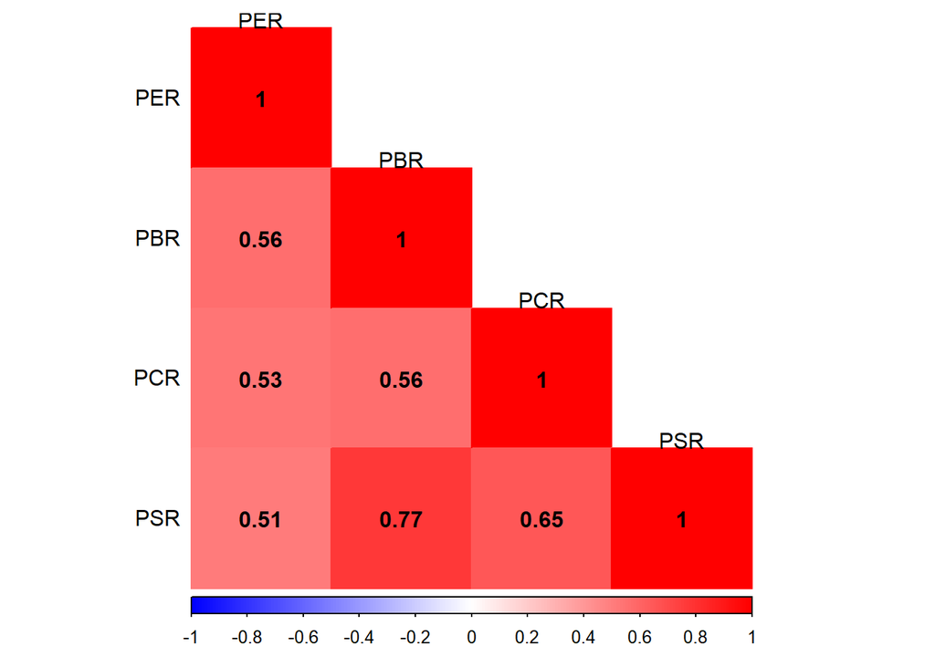

```r
# Rank transform valuation matrix
rank_value = KOR_value %>%
  mutate_all(list(~min_rank(.)))

cor(rank_value, use = 'complete.obs') %>%
  round(., 2) %>%
  corrplot(method = 'color', type = 'lower',
           addCoef.col = 'black', number.cex = 1,
           tl.cex = 1, tl.srt = 0, tl.col = 'black',
           col = colorRampPalette(
             c('blue', 'white', 'red'))(200),
           mar=c(0,0,0.5,0))
```

**Code Breakdown**

- `mutate_all()` from the `dplyr` package is used to transform all columns in the dataframe. The transformation applied is `min_rank(.)`, which ranks the data in each column (smaller numbers get lower ranks).
  - The result is stored in `rank_value`, which now contains the rank-transformed data.
- `cor(rank_value, use = 'complete.obs')` calculates the correlation matrix for the `rank_value` dataframe. `use = 'complete.obs'` ensures that only complete cases (rows without any `NA` values) are used in the correlation calculation.
  - `round(., 2)` rounds the correlation values to two decimal places.
- **`corrplot()`**
  - `method = 'color'` specifies that the correlations should be displayed using colored tiles.
  - `type = 'lower'` indicates that only the lower triangle of the correlation matrix should be displayed.
  - `addCoef.col = 'black'` sets the color of the correlation coefficients (numbers) added to the plot.
  - `number.cex = 1` adjusts the size of the correlation coefficients.
  - `tl.cex = 1` and `tl.srt = 0` control the size and rotation of the text labels (tick labels) on the axes.
  - `tl.col = 'black'` sets the color of the text labels.
  - `col = colorRampPalette(c('blue', 'white', 'red'))(200)` defines a color palette ranging from blue (negative correlation) through white (no correlation) to red (positive correlation).
  - `mar=c(0,0,0.5,0)` sets the margins around the plot.

**Understanding `mutate_all()` and `list()`**

- **`mutate_all()` Function**:
  - `mutate_all()` is used to apply a function or a set of transformations to every column in a dataframe. This is particularly useful when you want to perform the same operation across all columns.
- **Use of `list()`**:
  - In this context, `list()` is used to specify a set of functions or transformations to be applied. The syntax `list(~function(.))` allows for a concise way to define the transformation using a formula interface. Here, the tilde `~` creates a formula, and the dot `.` is a placeholder for the column being processed.
- **Why Use `list()`:**
- In `dplyr` version 1.0.0 and later, the use of `list()` in `mutate_all()` is recommended for defining transformations. It provides a cleaner, more standardized way to write code, especially when applying multiple functions.
- The use of `list()` becomes more evident when applying multiple functions. For example, if you wanted to apply both `min_rank()` and another transformation (let’s say `log1p`), you could write it as `mutate_all(list(~min_rank(.), ~log1p(.)))`.
- The formula interface (`~`) inside `list()` is a tidyverse convention, providing a consistent way to define expressions applied to dataframe columns.

Hence, we can say that the use of `list()` in conjunction with `mutate_all()` provides a flexible and clear way to apply transformations across all columns of a dataframe, adhering to tidyverse syntax and enabling the easy extension to multiple functions if needed.

Notice that correlations between some of these ratios are close 0.5, lower than what one would expect from the same value factor. Hence, we proceed to select a new value portfolio considering all ranks.

```r
# Sum rankings for each valuation ratio across the row
rank_sum <- rowSums(rank_value)

# Find new ranking based on rowsums
KOR_value[rank(rank_sum) <= 30,]
```

```
##              PER        PBR       PCR        PSR
## 4360   2.0792565 0.21838927 2.9575389 0.16983387
## 101330 4.2846628 0.19776985 0.8287208 0.06070666
## 1250   2.9039658 0.50125005 0.9954023 0.04020162
## 3070   1.4430501 0.37267268 0.8612132 0.08069013
## 3380   3.3326263 0.16072278 0.6532462 0.05903035
## 37400  5.1818809 0.12362686 0.8886801 0.02667006
## 1940   3.6609702 0.19525827 2.9750043 0.16135282
## 5010   1.1833624 0.29571045 1.3032474 0.26080118
## 36710  4.0462206 0.21157962 0.3180477 0.07830326
## 2020   1.6381223 0.19458908 0.9399849 0.03970925
## 7860   2.6330204 0.17284196 0.6877370 0.05336492
## 880    1.3995496 0.08795951 0.9804543 0.02948838
## 9200   6.4330183 0.14183620 2.3336964 0.06988913
## 13580  2.1478462 0.16186435 4.5276898 0.04405353
```

[output cut: 16 more lines]

Some nuance you could add is to give a weight to each valuation ratio; that is, you do not treat each valuation ratio equally. This is certainly a topic worthy of discussion, but we should also acknowledge that most often time, simple is the best. Hence, I expect using equally weighted rankings of each valuation ratio is good enough in practice as well.

Another important point is that there are a lot of NA values recorded, so we are essentially ignoring these stocks (negative earnings, cash flow, or just unavailable data). It should be taken into considerating when carrying out such strategy in practice.

```r
# Extract necessary information
invest_value <- rank(rank_sum) <= 30

KOR_ticker[invest_value,] %>% select('종목코드', '종목명', '시가총액', '업종명') %>%
  mutate('PBR' = KOR_value[invest_value, "PBR"] %>% round(2),
         'PER' = KOR_value[invest_value, "PER"] %>% round(2),
         'PCR' = KOR_value[invest_value, "PCR"] %>% round(2),
         'PSR' = KOR_value[invest_value, "PSR"] %>% round(2)
  )
```

```
##      종목코드           종목명     시가총액     업종명  PBR  PER  PCR  PSR
## 279    004360             세방 8.679256e+11 운수창고업 0.22 2.08 2.96 0.17
## 363    101330         모베이스 1.034994e+11     IT부품 0.20 4.28 0.83 0.06
## 464    001250         GS글로벌 2.310945e+11     유통업 0.50 2.90 1.00 0.04
## 481    003070     코오롱글로벌 2.834227e+11     건설업 0.37 1.44 0.86 0.08
## 490    003380         하림지주 1.934337e+12       금융 0.16 3.33 0.65 0.06
## 569    037400 우리엔터프라이즈 4.334719e+10       유통 0.12 5.18 0.89 0.03
## 610    001940      KISCO홀딩스 3.526451e+11   철강금속 0.20 3.66 2.98 0.16
## 710    005010           휴스틸 3.921928e+11   철강금속 0.30 1.18 1.30 0.26
## 865    036710       심텍홀딩스 1.409407e+11     IT부품 0.21 4.05 0.32 0.08
## 1012   002020           코오롱 2.670489e+11   기타금융 0.19 1.64 0.94 0.04
## 1025   007860             서연 2.002831e+11   기타금융 0.17 2.63 0.69 0.05
## 1080   000880             한화 2.211283e+12       화학 0.09 1.40 0.98 0.03
## 1112   009200       무림페이퍼 1.073520e+11   종이목재 0.14 6.43 2.33 0.07
## 1252   013580         계룡건설 1.535223e+11     건설업 0.16 2.15 4.53 0.04
```

[output cut: 16 more lines]

We observe decent number of stocks are from material and utilities sector. We see more firms from the utilities sector than before (when just using PBR to screen).

Next, we take a look at the intersection between the above value portfolio and that constructed from only using the PBR.

```r
intersect(KOR_ticker[invest_PBR, '종목명'],
          KOR_ticker[invest_value, '종목명'])
```

```
##  [1] "하림지주"         "우리엔터프라이즈" "서연"             "한화"
##  [5] "무림페이퍼"       "계룡건설"         "동국제강"         "이마트"
##  [9] "CJ"               "SNT홀딩스"
```

Surprisingly, there are only 10 common stocks between the two groups. This indicates which value ratio you refer to when selecting constituents of your value portfolio actually matters.

## Quality Factor

Quality is general compared to other fundamental factors; thus, we can have many forms of the factor. Below are some of the mainstream standards used to gauage quality of a company.

1. Profitability
2. Earnings stability
3. Capital Structure
4. Growth
5. Accounting Quality
6. Payout/Dilution (Dividends, Buyback etc)
7. Investment (CAPEX, OPEX etc)

For this section, we will be importing the list that contains financial statements for all publicly listed stocks and the ticker file.

1. RDS file containing financial statements of all publicly listed Korean companies (stored in the form of list)
2. KOR_ticker (excel file containing stock info of all tickers)

```r
# Import libraries
library(stringr)
library(ggplot2)
library(dplyr)
library(openxlsx)
```

```r
# Import files
KOR_fs <- readRDS("KOR_fs_clean.Rds")
KOR_ticker <- read.xlsx("KOR_ticker_2023-04-20.xlsx")

# Check attributes of first 3 elements of Rds file
KOR_fs[1:3] %>% str()
```

```
## List of 3
##  $ 매출액    : tibble [2,336 × 4] (S3: tbl_df/tbl/data.frame)
##   ..$ stockcode: chr [1:2336] "320000" "145210" "010580" "000250" ...
##   ..$ X2020.12 : num [1:2336] 112 768 707 1669 NA ...
##   ..$ X2021.12 : num [1:2336] 154 527 731 1673 NA ...
##   ..$ X2022.12 : num [1:2336] 203 582 1368 1773 NA ...
##  $ 매출원가  : tibble [2,336 × 4] (S3: tbl_df/tbl/data.frame)
##   ..$ stockcode: chr [1:2336] "320000" "145210" "010580" "000250" ...
##   ..$ X2020.12 : num [1:2336] 89 698 682 729 NA ...
##   ..$ X2021.12 : num [1:2336] 124 538 744 842 NA ...
##   ..$ X2022.12 : num [1:2336] 155 543 1179 873 NA ...
##  $ 매출총이익: tibble [2,336 × 4] (S3: tbl_df/tbl/data.frame)
##   ..$ stockcode: chr [1:2336] "320000" "145210" "010580" "000250" ...
##   ..$ X2020.12 : num [1:2336] 23 70 25 940 NA -12 432 89 -75 -476 ...
##   ..$ X2021.12 : num [1:2336] 30 -11 -13 831 NA 8 558 244 87 152 ...
##   ..$ X2022.12 : num [1:2336] 48 39 189 900 NA ...
```

```r
KOR_fs[[1]]
```

```
## # A tibble: 2,336 × 4
##    stockcode X2020.12 X2021.12 X2022.12
##    <chr>        <dbl>    <dbl>    <dbl>
##  1 320000         112      154      203
##  2 145210         768      527      582
##  3 010580         707      731     1368
##  4 000250        1669     1673     1773
##  5 131100          NA       NA       NA
##  6 051980         108      130      291
##  7 014580        1653     1952     3451
##  8 037370         451      957      702
##  9 011300        1280      789      725
## 10 006380        2547     5824     4272
## # ℹ 2,326 more rows
```

We see from above that each element represents a financial account (in tibble data format), for each element we have a column of all stock tickers and 3 columns representing values of the financial account corresponding to the end of financial years of 2020, 2021, and 2022.

### Constructing Quality Portfolio Based on F - Score

The F-score is a measurement concocted by professor Piotroski in his paper from 2000. He argued that just investing in low PBR stocks is quite dangerous, so investors should screen for high quality stocks among the low PBR stocks.

Below is a summary of the F-score, which distinguishes financial quality into 3 criterion and a total of 9 measurements.

| Category | Metric | Explanation |
| --- | --- | --- |
| Profitability | ROA | 1 if ROA is positive |
| Profitability | CFO | 1 if CFO is positive |
| Profitability | ΔROA | 1 if ROA increased compared to the last year |
| Profitability | ACCRUAL | 1 if CFO > ROA |
| Financial Performance | ΔLEVER | 1 if Financial leverage decreased in the past year |
| Financial Performance | ΔLIQUID | 1 if Liquidity increased in the past year |
| Financial Performance | EQ_OFFER | 1 if No new equity offerings in the past year |
| Operating Efficiency | ΔMARGIN | 1 if Gross margin increased in the past year |
| Operating Efficiency | ΔTURN | 1 if Asset turnover increased in the past year |

Basically, we can give a score of either 1 or 0 for each standard. Then we compute the sum of all F-indices and choose the stocks with a F-score of 9 to form the quality factor portfolio.

Before calculating the metric values, we must make sure that we are dividing by the numeric values. When naively performing `KOR_fs$'당기순이익' / KOR_fs$'자산'`, we encounter an error since the first column of each element is a column containing character values.

Thus, we compute the division by specifying second to fourth columns, then append the ‘stock code’ column on the left.

```r
# Profitability
ROA = (KOR_fs$'당기순이익'[,2:4] / KOR_fs$'자산'[,2:4]) %>% mutate("stock code" = KOR_fs[[1]]$stockcode) %>% select("stock code", everything())

CFO = (KOR_fs$'영업활동으로인한현금흐름'[,2:4] / KOR_fs$'자산'[,2:4]) %>% mutate("stock code" = KOR_fs[[1]]$stockcode) %>% select("stock code", everything())

ACCRUAL = (CFO[,2:4] - ROA[,2:4]) %>% mutate("stock code" = KOR_fs[[1]]$stockcode) %>% select("stock code", everything())

# Financial Performance
LEV = (KOR_fs$'장기차입금'[,2:4] / KOR_fs$'자산'[,2:4]) %>% mutate("stock code" = KOR_fs[[1]]$stockcode) %>% select("stock code", everything())

LIQ = (KOR_fs$'유동자산'[,2:4] / KOR_fs$'유동부채'[,2:4]) %>% mutate("stock code" = KOR_fs[[1]]$stockcode) %>% select("stock code", everything())

OFFER = KOR_fs$'유상증자'

# Operating Efficiency
MARGIN = (KOR_fs$'매출총이익'[,2:4] / KOR_fs$'매출액'[,2:4]) %>% mutate("stock code" = KOR_fs[[1]]$stockcode) %>% select("stock code", everything())

TURN = (KOR_fs$'매출액'[,2:4] / KOR_fs$'자산'[,2:4]) %>% mutate("stock code" = KOR_fs[[1]]$stockcode) %>% select("stock code", everything())
```

For ROA, we use net earnings and total assets.

For leverage, we use long-term debt and total assets.

For liquidity, we use current assets and current liabilities.

For OFFER, we use equity issuance.

For MARGIN, we use the gross profit margin.

For TURN, or turnover, we refer to asset turnover (revenue over total assets).

Now, we construct code that assesses either 1 or 0 for each index.

**Note on data availability**

If data is downloaded from January to April, there is a tendency for last year data to not include the full data. Thus, we must resort to data from *2 years ago*. We make the assumption that the code is executed close to the data in which the data was downloaded. Thus, we use `Sys.Date()` function to calculate current date, extract the month and then form an `if then` statement to store the appropriate column index.

```r
# Check whether month is one of 1, 2, 3, or 4

  if (lubridate::month(Sys.Date()) %in% c(1,2,3,4)) {
    col_num <- str_which(colnames(KOR_fs[[1]]), as.character(lubridate::year(Sys.Date()) - 2))
  } else {
    col_num <- str_which(colnames(KOR_fs[[1]]), as.character(lubridate::year(Sys.Date()) - 1))
  }

col_num
```

```
## [1] 4
```

The 4th column of each dataframe corresponds to the most recent year (last column).Now we proceed to calculate all the F-indices.

```r
# Calculate F_1 through F_9
F_1 <- as.integer(ROA[, col_num] > 0)
F_2 <- as.integer(CFO[, col_num] > 0)
F_3 <- as.integer((ROA[, col_num] - ROA[, col_num - 1]) > 0)
F_4 <- as.integer(ACCRUAL[,col_num] > 0)
F_5 <- as.integer((LEV[, col_num] - LEV[, col_num - 1]) <= 0)
F_6 <- as.integer((LIQ[, col_num] - LIQ[, col_num - 1]) > 0)
F_7 = as.integer(is.na(OFFER[,col_num]) |
                   OFFER[,col_num] <= 0)
F_8 = as.integer(MARGIN[, col_num] -
                   MARGIN[, (col_num-1)] > 0)
F_9 = as.integer(TURN[,col_num] - TURN[,(col_num-1)] > 0)

# For F-score table
F_table <- cbind(F_1, F_2, F_3, F_4, F_5, F_6, F_7, F_8, F_9)
head(F_table)
```

```
##      F_1 F_2 F_3 F_4 F_5 F_6 F_7 F_8 F_9
## [1,]   1   1   1   1  NA   0   1   1   1
## [2,]   0   0   0   1   0   0   0   1   1
## [3,]   1   1   1   0  NA   1   1   1   0
## [4,]   1   1   1   1  NA   1   1   1   0
## [5,]  NA  NA  NA  NA  NA  NA   1  NA  NA
## [6,]   0   0   0   1   0   0   0   1   1
```

**Treatment of NA values** An important subtlety to mention is that we ignore the NA values, since we cannot make any assumption of the value replacing NA (we do not know if quality score is low or high).

Next, we sum up across the rows, and then show a distribution plot that shows how stocks are distrbuted across the F-scores. If we use `rowSums()`, the inclusion of any NA value in a single row will result in the sum being NA. Instead, we use `apply(., 1, na.rm = TRUE)` to ignore NA values when taking the sum across the rows.

```r
# Calculate F_score
F_score <- F_table %>%
  apply(., 1, sum, na.rm = TRUE) %>%
  setNames(KOR_ticker$`종목명`)

# Find distribution of stock F-scores
F_dist = prop.table(table(F_score)) %>% round(3)
```

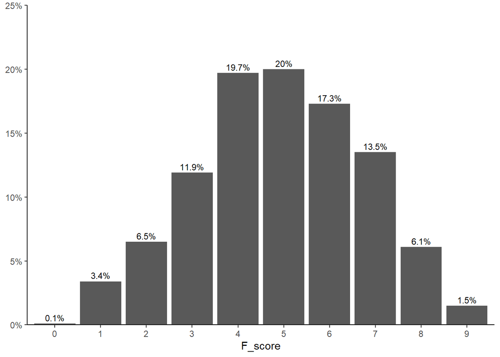

```r
# plot F-score distribution
F_dist %>%
  data.frame() %>%
  ggplot(aes(x = F_score, y = Freq,
             label = paste0(Freq * 100, '%'))) +
  geom_bar(stat = 'identity') +
  geom_text(color = 'black', size = 3, vjust = -0.4) +
  scale_y_continuous(expand = c(0, 0, 0, 0.05),
                     labels = scales::percent) +
  ylab(NULL) +
  theme_classic()
```

We notice that most stocks are distributed across an F-score of 3 ~ 7.

Next, we choose the stocks with F-score of 9.

```r
# Select stocks with F-score of 9
invest_F_score <- F_score %in% c(9)

# Display info
KOR_ticker[invest_F_score,] %>% select('종목코드', '종목명', '시가총액', '업종명') %>% mutate(`F-Score` = F_score[invest_F_score])
```

```
##      종목코드         종목명     시가총액        업종명 F-Score
## 28     317830 에스피시스템스 1.459789e+11     기계·장비       9
## 69     091580     상신이디피 3.550151e+11        IT부품       9
## 125    030520   한글과컴퓨터 3.792728e+11    소프트웨어       9
## 140    123040   엠에스오토텍 2.540850e+11 운송장비·부품       9
## 164    118990       모트렉스 4.948091e+11 운송장비·부품       9
## 176    013310       아진산업 1.430023e+11 운송장비·부품       9
## 202    197140         디지캡 4.790427e+10 출판·매체복제       9
## 211    263020     디케이앤디 5.077134e+10          화학       9
## 216    024910       경창산업 8.542833e+10 운송장비·부품       9
## 254    085670       뉴프렉스 1.607528e+11        IT부품       9
## 294    187270       신화콘텍 4.879189e+10        IT부품       9
## 333    200880       서연이화 3.773170e+11      운수장비       9
## 437    010690           화신 4.735208e+11      운수장비       9
## 522    263800   데이타솔루션 1.082720e+11      정보기기       9
```

[output cut: 21 more lines]

There are a total of 35 stocks when screened using the F-score. We see a concentration of stocks from equipment sector. Interestingly, there are no mega cap stocks when screened, though we cannot know whether this occurred due to the missing values or not.

### Construct Portfolio Based on Ranking of Aggregate Quality Indices

This time, we aggregate rankings of ROE, Gross Profit, and Operating Cash Flow and choose stocks with the lowest rank sum.

```r
# Import libraries
library(stringr)
library(ggplot2)
library(dplyr)
library(tidyr)
library(corrplot)
```

```r
# Import files
KOR_fs <- readRDS("KOR_fs_clean.Rds")
KOR_ticker <- read.xlsx("KOR_ticker_2023-04-20.xlsx")
```

```r
if (lubridate::month(Sys.Date()) %in% c(1,2,3,4) ) {
  num_col = str_which(colnames(KOR_fs[[1]]), as.character(lubridate::year(Sys.Date()) - 2))
} else {
  num_col = str_which(colnames(KOR_fs[[1]]), as.character(lubridate::year(Sys.Date()) - 1))
}

roe = ((KOR_fs$'당기순이익'[,2:4] / KOR_fs$'자본'[,2:4]) %>% mutate("stock code" = KOR_fs[[1]]$stockcode) %>% select("stock code", everything()))[num_col]
gpa = ((KOR_fs$'매출총이익'[,2:4] / KOR_fs$'자산'[,2:4]) %>% mutate("stock code" = KOR_fs[[1]]$stockcode) %>% select("stock code", everything()))[num_col]
cfo = ((KOR_fs$'영업활동으로인한현금흐름'[,2:4] / KOR_fs$'자산'[,2:4]) %>% mutate("stock code" = KOR_fs[[1]]$stockcode) %>% select("stock code", everything()))[num_col]

quality_profit =
  cbind(roe, gpa, cfo) %>%
  setNames(c('ROE', 'GPA', 'CFO'))
```

Since higher quality measurements are more desirable, we rank in a descending order.

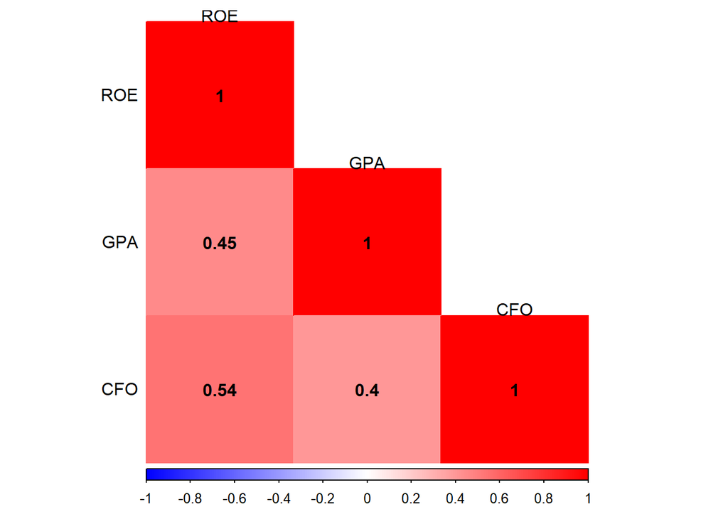

```r
rank_quality = quality_profit %>%
  mutate_all(list(~min_rank(desc(.))))

cor(rank_quality, use = 'complete.obs') %>%
  round(., 2) %>%
  corrplot(method = 'color', type = 'lower',
           addCoef.col = 'black', number.cex = 1,
           tl.cex = 1, tl.srt = 0, tl.col = 'black',
           col =
             colorRampPalette(c('blue', 'white', 'red'))(200),
           mar=c(0,0,0.5,0))
```

Notice profitability indices have relatively low correlation with each other, so we can expect diversification effects by aggregating the rankings.

```r
# Sum rank
rank_sum = rank_quality %>%
  rowSums()

invest_quality = rank(rank_sum) <= 30

KOR_ticker[invest_quality, ] %>%
  select('종목코드', '종목명', '시가총액', '업종명') %>%
  cbind(round(quality_profit[invest_quality, ], 4))
```

```
##      종목코드           종목명     시가총액        업종명    ROE    GPA    CFO
## 60     335890             비올 3.079990e+11 의료·정밀기기 0.3020 0.5112 0.2646
## 170    215000           골프존 7.066117e+11    소프트웨어 0.2990 0.6170 0.2271
## 183    336570             원텍 5.724045e+11 의료·정밀기기 0.2347 0.6612 0.2005
## 240    199730     바이오인프라 1.196818e+11    기타서비스 0.3464 0.4294 0.2577
## 295    205470         휴마시스 4.618688e+11          제약 0.5267 0.5474 0.4334
## 328    348210           넥스틴 6.581362e+11        반도체 0.4357 0.6444 0.4216
## 343    084650       랩지노믹스 2.412800e+11    기타서비스 0.2276 0.3861 0.2752
## 399    411080           샌즈랩 2.126919e+11    소프트웨어 1.1000 0.9490 0.3571
## 432    058630           엠게임 1.774584e+11  디지털컨텐츠 0.2427 0.6332 0.3187
## 491    140860     파크시스템스 1.037315e+12 의료·정밀기기 0.2343 0.4880 0.1653
## 575    287410   제이시스메디칼 6.655011e+11 의료·정밀기기 0.3375 0.6740 0.2142
## 652    000990         DB하이텍 2.925867e+12      전기전자 0.3411 0.4396 0.3439
## 772    403870             HPSP 1.635354e+12        반도체 0.3378 0.4220 0.3147
## 812    215200   메가스터디교육 7.413675e+11    기타서비스 0.2297 0.5235 0.1824
```

[output cut: 16 more lines]